# fish regression

> Let us do influence plot to deepen our understanding.

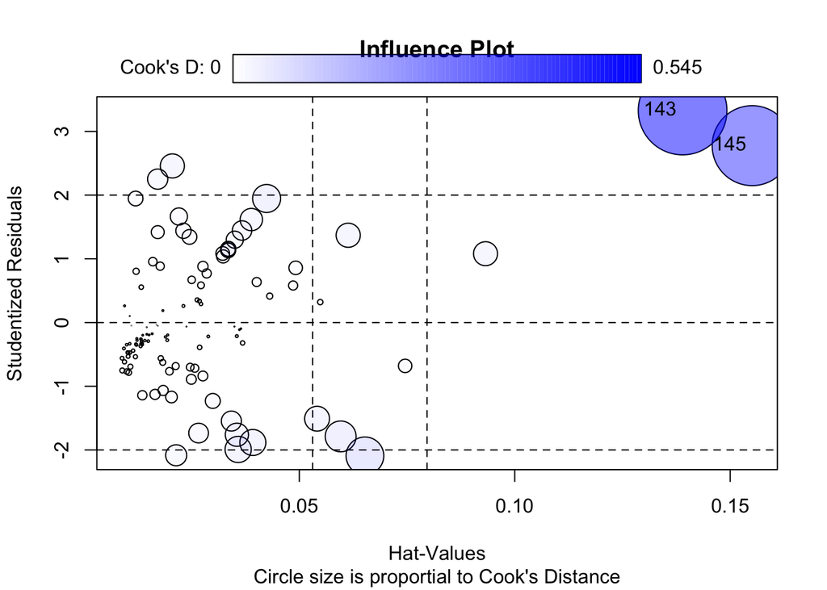

```
##      StudRes       Hat     CookD
## 143 3.326911 0.1389567 0.5454811
## 145 2.776375 0.1551048 0.4445783
```

```r
influencePlot(fish.hl3.reg, id.method="identify", main="Influence Plot", sub="Circle size is proportial to Cook's Distance" )
```

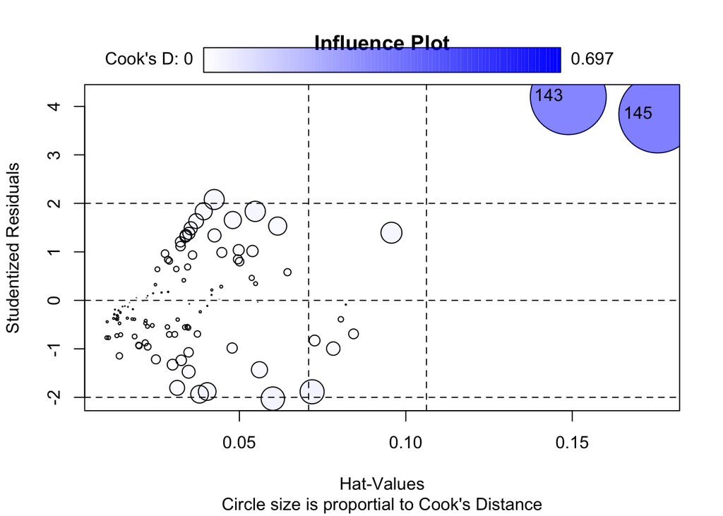

```
##      StudRes       Hat     CookD
## 143 4.199627 0.1488134 0.6687873
## 145 3.838729 0.1756420 0.6970795
```

```r
influencePlot(fish.hl13.reg, id.method="identify", main="Influence Plot", sub="Circle size is proportial to Cook's Distance" )
```

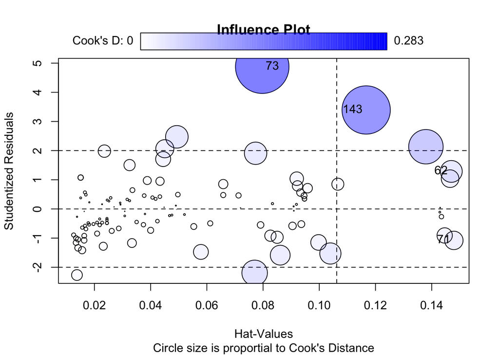

```
##       StudRes        Hat      CookD
## 62   1.286927 0.14696900 0.04726749
## 71  -1.079482 0.14787488 0.03365116
## 73   4.877535 0.07970216 0.28309524
## 143  3.394170 0.11667916 0.23091985
```

```r
influencePlot(fish.sel2.reg, id.method="identify", main="Influence Plot", sub="Circle size is proportial to Cook's Distance" )
```

> Points in the top right corner are outliers having high impact on the regression but I can not understand why. Lets check VIF scores to evaluate multicollinearity in the model.

```r
vif(fish.hl3.reg) # variance inflation factors
```

```
##   Height  Length3
## 2.002794 2.002794
```

```r
vif(fish.hl13.reg)
```

```
##     Height    Length3    Length1
##   5.801885 212.363933 175.152832
```

```r
vif(fish.sel2.reg)
```

```
##       Length1       Length2 SpeciesParkki   SpeciesPike  SpeciesSmelt
##   1415.580182   1415.980669      1.111674      1.700591      1.698921
```

> VIF of model 1 is <5 indicating that there is no significant multicollinearity between predictor varaibles VIF of model 2 and 3 is >5 indicating severe multicollinearity between predictor variables. We have to reduce the impact of outliers in our model to make it more robust. Also, Length1 and Length3 predictors are highly correlated.